# Customer Churn Analytics for a Stationery Business

An Analysis of My Family Business

Parsa Keyvani

August 2022

# Introduction

It is more expensive to acquire new customers than sell more to an existing client. Customer churn is a fundamental problem and one of the most important concerns for companies. Due to its direct effect on companies’ revenues, many companies seek to develop means to predict potential customer churn and to detect factors that contribute to it so they can take necessary actions for its mitigation (Ahmad, Jafar, and Aljoumaa (2019)). Reducing customer churn can lead to increased profits, improved customer experience, optimized products and services, and higher customer retention (Kriti (2019)). The main contribution of my work is to gain a deeper understanding of my family business customer behavior and develop an accurate churn prediction model which assists the company in predicting customers who are most likely subject to churn. Moreover, I propose actionable plans to reduce churn by utilizing the two analyses above. Therefore, this study covers all four aspects of analytics: descriptive, diagnostic, predictive, and prescriptive.

# Data Characteristics

The company manufactures four products: binders, lever arches, clipboards, and file boxes with many color and size variations. 90% of the company’s revenues come from lever arches, making it the top revenue-generating product for the company. The data is extracted directly from the company. A total of 12 datasets were collected, including six, each indicating company sales for an entire year from 2016 to 2021 for all the products and another six for the returned product sales for the six years. Each dataset is recorded by transactions, where each row indicates a purchase made by a customer. Each dataset contains 45 different variables that the company controls for. There are a total of 88683 entries of sales data and a total of 1362 entries of returns data in all six years, which already shows a meager return-to-sales ratio. All the values in each column are recorded in the Farsi language, and the dates are in Jalili format (Persian Calendar).

```r
# Reading the sales data files.
sales_1395<-read_xlsx("Sales_Data/Sales_1395.xls")
sales_1396<-read_xlsx("Sales_Data/Sales_1396.xls")
sales_1397<-read_xlsx("Sales_Data/Sales_1397.xls")
sales_1398<-read_xlsx("Sales_Data/Sales_1398.xls")
sales_1399<-read_xlsx("Sales_Data/Sales_1399.xls")
sales_1400<-read_xlsx("Sales_Data/Sales_1400.xls")

# Reading the returned sales data files.
returns_1395<-read_xlsx("Sales_Return/Returns_1395.xls")
returns_1396<-read_xlsx("Sales_Return/Returns_1396.xls")
returns_1397<-read_xlsx("Sales_Return/Returns_1397.xls")
returns_1398<-read_xlsx("Sales_Return/Returns_1398.xls")
returns_1399<-read_xlsx("Sales_Return/Returns_1399.xls")
returns_1400<-read_xlsx("Sales_Return/Returns_1400.xls")
```

Total Number of Rows in All Datasets and Number of Columns in each Dataset

| Dataset | Rows | Columns |
| --- | --- | --- |
| sales | 88683 | 45 |
| returns | 1362 | 45 |

## Data Manipulation and Transformation

From the list of 45 variables in sales and returned sales datasets, I identified and selected the variables that would help with my churn analyses, as shown below.

```r
# Creating a function that selects desired variables, renames, and drops na's from the sales datasets.
sales_modify <- function (dataset) {
  dataset<-dataset %>%
    rename(Date = "تاريخ",
           Units = "مقدار",
           Discount = "تخفيف",
           Product_Name= "نام كالا",
           Product_ID = "كد كالا",
           Unit_Price= "قيمت واحد",
           Total_Sales = "مبلغ كل",
           Customer_Name= "مشترى - تفصيلى شناور") %>%
    transmute(Date = as.Date(Date, "%Y/%m/%d"), Product_Name, Product_ID, Units, Unit_Price,
              Discount, Customer_Name, Total_Sales) %>%
    drop_na()
  return(dataset)
}

# Using above function on the six sales datasets.
sales_1395 <- sales_modify(sales_1395)
sales_1396 <- sales_modify(sales_1396)
sales_1397 <- sales_modify(sales_1397)
sales_1398 <- sales_modify(sales_1398)
sales_1399 <- sales_modify(sales_1399)
sales_1400 <- sales_modify(sales_1400)

# Creating a function that selects, renames, and drops na's from the returns datasets.
returns_modify<- function (dataset) {
  dataset<-dataset %>%
    dplyr::rename(Units_Returned = "مقدار",
           Product_Name= "نام كالا",
           Product_ID = "كد كالا",
           Customer_Name= "مشترى - تفصيلى شناور") %>%
    dplyr::transmute(Customer_Name, Product_Name, Product_ID, Units_Returned) %>%
    drop_na()
  return(dataset)
}

# Using above function on the six returned sales datasets.
returns_2016 <- returns_modify(returns_1395)
returns_2017 <- returns_modify(returns_1396)
returns_2018 <- returns_modify(returns_1397)
returns_2019 <- returns_modify(returns_1398)
returns_2020 <- returns_modify(returns_1399)
returns_2021 <- returns_modify(returns_1400)
```

Next, I converted Jalili dates to Gregorian dates as shown below.

```r
# A function that converts Jalali dates to Gregorian dates for each dataset.
dates_modify<- function (dataset) {
  # Seperating Year, Month, Day from Date column.
  Year<-format(dataset$Date, format = "%Y")
  Month <-format(dataset$Date, format = "%m")
  Day <-format(dataset$Date, format = "%d")
  # Initializing an empty date tibble.
  date_tibble <- tibble(
    Date = as.Date(character()))
  # Converting Jalali dates to Gregorian dates.
  i <- 1
  while (i<=nrow(dataset)){
    date_tibble<- add_row(date_tibble, Date = jal2greg(Year[i], Month[i], Day[i]))
    i=i+1
  }
  # Adding Gregorian dates to the dataset and removing Jalili Date column.
  dataset<-dplyr::select(dataset,-Date)
  dataset <- tibble(date_tibble, dataset)
  #dataset <- select(dataset,-Date)
  return(dataset)
}

sales_2016 <- dates_modify(sales_1395)
sales_2017 <- dates_modify(sales_1396)
sales_2018 <- dates_modify(sales_1397)
sales_2019 <- dates_modify(sales_1398)
sales_2020 <- dates_modify(sales_1399)
sales_2021 <- dates_modify(sales_1400)
```

The number of distinct product names resulted in more than 200 instances in the datasets; However, the company only manufactures four products: binders, lever arches, file boxes, and clipboards. This is caused by including the color and sizes of each product in their product name. The datasets do not have different variables to measure products’ color and dimensions, which is why color and size are included in their names. Additionally, the values do not have a uniform convention due to the lack of data validation during data entry. Therefore, the product name variable needs to be adjusted to only include four different products and not 200. Also, this project does the customer analyses only on lever arches as it generates the most revenue for the company. Hence, I filtered product names by lever arch to only include data on this product.

```r
# Product name modified to have only 4 distinct product.
ProductNameModify<-function (dataset) {
  i<-1
  while (i<=nrow(dataset)){
    if (str_detect(dataset[i,2], "مقوا|چسب|جلد|كارت ليبل|كلاسور") && !str_detect(dataset[i,2], "تخته شاسى|قفل|جامجله اى")) {
      dataset[i,2]= "Binder"}
    else if (str_detect(dataset[i,2], "فيلتر|قفل|چفت")) {
      dataset[i,2]= "Lever Arch"}
    else if (str_detect(dataset[i,2], "جامجله اى|پاكت|پوشه|فولدر|كيف|كلر بوك|ديوايدر|ML 310|فايل باكس")) {
      dataset[i,2]= "FileBox"}
    else if (str_detect(dataset[i,2], "Lexi |پك ملزومات")){
      dataset[i,2]= "other"}
    else if (str_detect(dataset[i,2], "زير دستى|تخته شاسى")) {
      dataset[i,2]= "ClipBoard"}
    i=i+1
  }
  return(dataset)
}

sales_2016<-ProductNameModify(sales_2016)
sales_2017<-ProductNameModify(sales_2017)
sales_2018<-ProductNameModify(sales_2018)
sales_2019<-ProductNameModify(sales_2019)
sales_2020<-ProductNameModify(sales_2020)
sales_2021<-ProductNameModify(sales_2021)

returns_2016 <- ProductNameModify(returns_2016)
returns_2017 <- ProductNameModify(returns_2017)
returns_2018 <- ProductNameModify(returns_2018)
returns_2019 <- ProductNameModify(returns_2019)
returns_2020 <- ProductNameModify(returns_2020)
returns_2021 <- ProductNameModify(returns_2021)
```

Next, I created a variable called frequency that counts the number of times a customer purchased in a given year. I also aggregated each dataset with the total number of lever arch units purchased, maximum unit price purchased, total discounts received, and total sales of lever arches for each customer in a given year.

```r
# calculating the frequency of purchases and converting to annual and aggregating the rest.
AnnualFrequeny<- function (dataset, year) {
  dataset<- dataset %>%
    group_by(Customer_Name) %>%
    summarise(frequency= n(),
              Units = sum(Units),
              Unit_Price= max(Unit_Price),
              Discount= sum(Discount),
              Total_Sales= sum(Total_Sales)) %>%
    arrange(desc(frequency)) %>%
    mutate(Year = year)
  return(dataset)}


br_sales_2016<-AnnualFrequeny(br_sales_2016,2016)
br_sales_2017<-AnnualFrequeny(br_sales_2017,2017)
br_sales_2018<-AnnualFrequeny(br_sales_2018,2018)
br_sales_2019<-AnnualFrequeny(br_sales_2019,2019)
br_sales_2020<-AnnualFrequeny(br_sales_2020,2020)
br_sales_2021<-AnnualFrequeny(br_sales_2021,2021)
```

Below, I calculated the total units returned by each customer. Then I merged the returns data of a given year with the sales data of the same year and combined all six datasets to produce one dataset that includes all the years’ data. I also eliminated the missing values for when units and tot_units_returned values were missing. I corrected missing values produced in tot_units_returned by replacing each with a zero.

```r
# calculating the total product returned by a costumer and then returns the merged data.
TotReturnedCalculate<- function (dataset1, dataset2) {
  dataset1<-dataset1 %>%
    group_by(Customer_Name) %>%
    summarise(tot_Units_Returned= sum(Units_Returned))
  merged_annual<- full_join(dataset1, dataset2, by = "Customer_Name")
  merged_annual<-select(merged_annual, c(Year, Customer_Name, Unit_Price, frequency, Units, tot_Units_Returned, Total_Sales, Discount))
  return(merged_annual)}

merged_2016<-TotReturnedCalculate(br_returns_2016,br_sales_2016)
merged_2017<-TotReturnedCalculate(br_returns_2017,br_sales_2017)
merged_2018<-TotReturnedCalculate(br_returns_2018,br_sales_2018)
merged_2019<-TotReturnedCalculate(br_returns_2019,br_sales_2019)
merged_2020<-TotReturnedCalculate(br_returns_2020,br_sales_2020)
merged_2021<-TotReturnedCalculate(br_returns_2021,br_sales_2021)

merged_2017<-merged_2017 %>%
  filter(!(is.na(Units) & !is.na(tot_Units_Returned)))
merged_2018<-merged_2018 %>%
  filter(!(is.na(Units) & !is.na(tot_Units_Returned)))

# merging all the rows of all 6 datasets to produce one dataset.
merged_data<-rbind(merged_2016,merged_2017,merged_2018,
                   merged_2019,merged_2020,merged_2021)

# replacing NA values with 0 for tot_Units_Returned variable.
merged_data<- merged_data %>%
  mutate(tot_Units_Returned= ifelse(is.na(tot_Units_Returned), 0, tot_Units_Returned))
```

Furthermore, significant corrections needed to be made for customers’ names. As a result of the inspection, some customers had “Mr.” and some did not, even though they were the same person. Another issue was extra spaces in their names, which did not match other instances of the same name. Additionally, some customers in the past have relegated their position to their children to operate. The customer name still needs to be the same in this case since the company has not changed. Similarly, when other people from the same company or store purchase, it should also count as the same customer. This transformation was the most challenging, and due to its complex nature, the corrections had to be done (for the most part) manually. I first took “Mr.” out of all the names, which helped solve some customers’ issues. For the rest of the names that needed to be fixed, I checked each name manually and looked to see if their last name matched any instances in the data. If it did, I checked their first names, if the first names did not match, then I contacted the company to check if they were related to the same company or store, and I corrected them accordingly. I used a similar technique for other cases as well. In total, 63 customer names were transformed out of 313 customers. Below, I show only a few customer name transformations to show some code.

The company produces lever arches of differing sizes—one in 7.5cm and another in 4.5cm, each with a different unit price. Due to the various costs of the two lever arch types, we need to aggregate unit price to the customer level because it will pose issues in predictive analytics. The analogy of the matter is like combining the prices of apples and oranges, which are not the same. To fix this issue, I transformed the unit price by taking the average unit price difference in percentage for both types of lever arches.

```r
# Removing "Mr" from the beginning of the names to fix matching issues
merged_data$Customer_Name<-gsub("آقاى ", "", as.character(merged_data$Customer_Name))

# Manual name corrections
merged_data$Customer_Name<-ifelse(str_detect(merged_data$Customer_Name, "K"), "KLIEMSTEIN",merged_data$Customer_Name)
merged_data$Customer_Name<-ifelse(str_detect(merged_data$Customer_Name, "بهزاد"), "بهزاد زيدى",merged_data$Customer_Name)
merged_data$Customer_Name<-ifelse(str_detect(merged_data$Customer_Name, "جلال حسينى"), "جلال حسينى",merged_data$Customer_Name)
merged_data$Customer_Name<-ifelse(str_detect(merged_data$Customer_Name, "عباس حسنى"), "عباس حسنى",merged_data$Customer_Name)
```

Moreover, I created a variable called Stayed that measures whether a customer stayed the next year or not; if the given customer was present in the next year, then it takes “yes”; otherwise, it takes “no.” as input.

```r
# A variable to determine whether the customers stayed the next year or not.
merged_data <- merged_data %>%
  arrange(Customer_Name)
merged_data$Stayed <- ifelse(merged_data$Customer_Name == lead(merged_data$Customer_Name), "yes", "no")
```

Lastly, I created another variable that measures how many years in total the customer had purchased lever arches from the company. I also removed values that had Unit Prices greater than 100000 rials because they belong in binders and were incorrectly placed in the lever arch category.

```r
# Number of years customer was present
arranged_data<-merged_data %>%
  arrange(Customer_Name)
occurence<- data.frame(table(arranged_data$Customer_Name))
occurence$Customer_Name <- occurence$Var1
occurence$num_years <- occurence$Freq
occurence<- occurence[3:4]
merged_data<-left_join(merged_data,occurence, by= "Customer_Name")

# removing binders that incorrectly were placed in lever arches.
merged_data<-merged_data %>%
  select(-Discount) %>%
  filter(Unit_Price <100000)
```

Below is the description of the data after all transformations and manipulations.

```
## merged_data
##
##  9  Variables      668  Observations
## --------------------------------------------------------------------------------
## Year
##        n  missing distinct     Info     Mean      Gmd
##      668        0        6    0.965     2019    2.111
##
## lowest : 2016 2017 2018 2019 2020, highest: 2017 2018 2019 2020 2021
##
## Value       2016  2017  2018  2019  2020  2021
## Frequency    141   113    77    59   146   132
## Proportion 0.211 0.169 0.115 0.088 0.219 0.198
## --------------------------------------------------------------------------------
## Customer_Name
##        n  missing distinct
##      668        0      313
##
## lowest :     توليدى جام سون - حسن انصارى     جواد جمشيدى                     رسول يخچالى                     على سعادت نيا                   كرمى
## highest: هادى ميرساعيان                   همايون ابراهيمى                  وحيد كريمى                       وزارت بهداشت و درمان آموزش پزشكى ولى  محمدى( قم)
## --------------------------------------------------------------------------------
## frequency
##        n  missing distinct     Info     Mean      Gmd      .05      .10
##      668        0       88    0.992    18.29       23      1.0      1.0
##      .25      .50      .75      .90      .95
##      2.0      7.0     23.0     45.3     67.3
##
## lowest :   1   2   3   4   5, highest: 156 194 197 271 283
## --------------------------------------------------------------------------------
## Units
##        n  missing distinct     Info     Mean      Gmd      .05      .10
##      668        0      426        1    98735   156760      100      400
##      .25      .50      .75      .90      .95
##     2605    20000    84470   208808   379020
##
## lowest :       8      10      11      15      20
## highest: 1750000 2132650 2302000 3583000 7116500
##
## 0 (443, 0.663), 1e+05 (125, 0.187), 2e+05 (45, 0.067), 3e+05 (18, 0.027), 4e+05
## (14, 0.021), 5e+05 (9, 0.013), 6e+05 (2, 0.003), 8e+05 (2, 0.003), 9e+05 (1,
```

[output cut: 34 more lines]

```
##
## Value         no   yes
## Frequency    311   357
## Proportion 0.466 0.534
## --------------------------------------------------------------------------------
## num_years
##        n  missing distinct     Info     Mean      Gmd
##      668        0        6    0.968    3.178    1.979
##
## lowest : 1 2 3 4 5, highest: 2 3 4 5 6
##
## Value          1     2     3     4     5     6
## Frequency    153   135   107    76   107    90
## Proportion 0.229 0.202 0.160 0.114 0.160 0.135
## --------------------------------------------------------------------------------
```

# Exploratory Analysis

## Independent Variables’ Performance Analysis

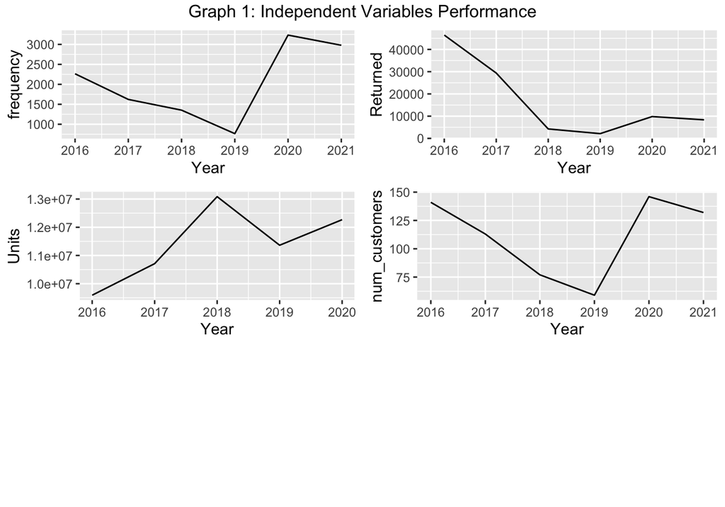

## Customer Churn and Retention Rate

Customer Churn Rate

| Year | Churn_rate | Retention_rate |
| --- | --- | --- |
| 2016 | 0.33 | 0.67 |
| 2017 | 0.37 | 0.63 |
| 2018 | 0.32 | 0.68 |
| 2019 | 0.27 | 0.73 |
| 2020 | 0.34 | 0.66 |

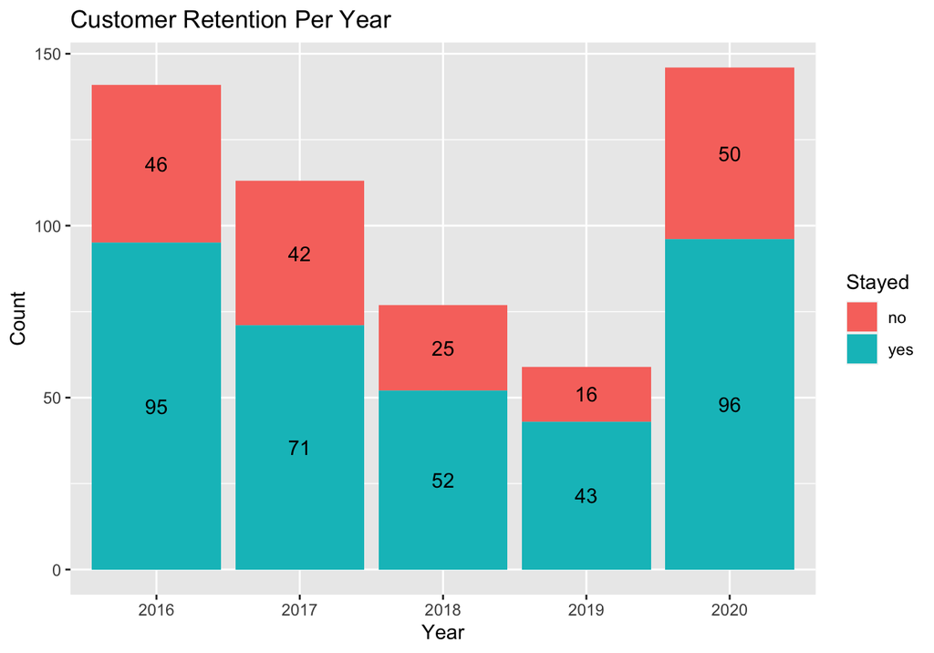

## Customer Loyalty Analysis

Customer loyalty is choosing one company’s products and services consistently over its competitors. Customers who are loyal to one company aren’t easily swayed by price or availability. They would rather pay more and ensure the same quality service and product they know and love. Customer loyalty results from a company consistently meeting and exceeding customer expectations. Another study by Rare Consulting says that 83% of customers said their brand loyalty stemmed from trust. In other words, loyalty is about likability and the ability to trust the product and brand. Customers who trust the companies they do business with will be more likely to purchase again. When a customer is loyal to a company, they are more likely to repeat their business. They are also more likely to recommend products and services to others. The importance of customer loyalty impacts almost every metric important to running a business. Without satisfied customers that continue to buy, the company won’t survive. New customers tend to cost more to acquire and don’t spend as much money as loyal, repeat customers. Keeping customers coming back for more is critical to business success. And it’s why short-term profit is not a good strategy. Table 3 depicts the most loyal customers of lever arches. Over the six years, the company acquired 313 unique lever arch customers. Among 313 customers throughout the six years, 15 never churned and were customers for the longest time. From the 15 most loyal customers, the top 10 customers with the highest total purchases (after adjusting for returns), and the highest shopping frequency, are shown below. These customers are the company’s most valuable customers, and the company needs to pay special attention to maintaining their satisfaction.

Customer Loyalty (Top 10 per sales)

| Customer_ID | frequency | Total_Sales_millions_toman | Total_Units_10thousands | years_loyal |
| --- | --- | --- | --- | --- |
| 12257783 | 672 | 9197 | 571 | 6 |
| 15962872 | 411 | 8901 | 727 | 6 |
| 13986105 | 774 | 5184 | 561 | 6 |
| 18039010 | 375 | 4038 | 253 | 6 |
| 18145985 | 127 | 1504 | 81 | 6 |
| 17797498 | 125 | 1317 | 74 | 6 |
| 13793878 | 212 | 1306 | 104 | 6 |
| 14076983 | 224 | 1234 | 69 | 6 |
| 14163772 | 162 | 1009 | 42 | 6 |
| 10300102 | 155 | 1008 | 61 | 6 |

## Revenue Growth Rate Analysis

Annual Revenue Growth Rate

| Year | Revenue_billions_toman | Revenue_Growth_rate |
| --- | --- | --- |
| 2016 | 4.566 | NA |
| 2017 | 5.373 | 17.7% |
| 2018 | 13.285 | 147.2% |
| 2019 | 17.078 | 28.5% |
| 2020 | 34.541 | 102.3% |
| 2021 | 43.737 | 26.6% |

## Purchasing Frequency Rate Analysis

Annual Average Consumer Purchasing Frequency

| Year | average_purchase_frequency |
| --- | --- |
| 2016 | 16.1 |
| 2017 | 14.4 |
| 2018 | 17.6 |
| 2019 | 13.0 |
| 2020 | 22.1 |
| 2021 | 22.6 |

## Product Return Rate Analysis

Product return rate refers to the frequency that customers return their purchased product. It is calculated as the percentage of sales orders with a product return. The return rate is an important metric as it highly impacts customer satisfaction and revenue. Customers make returns for many reasons, such as damaged products, inaccurate descriptions, incorrect products, incorrect sizes, malfunctioning products, delayed delivery, or a change of mind. Table 6 shows the lever arch return rate for each year. Overall, the return rate is outstanding, with returns being close to zero. The highest return rate was in 2016 at 0.48%, and the lowest was in 2019.

Annual Product Return Rate

| Year | Return_rate |
| --- | --- |
| 2016 | 0.48 |
| 2017 | 0.27 |
| 2018 | 0.03 |
| 2019 | 0.02 |
| 2020 | 0.08 |
| 2021 | 0.09 |

# Statistical Modeling

## Baseline Model

The baseline model was calculated by finding which of the two classes (yes and no) occurred more in Stayed variable and assigned all the values as just that class. In this case, we had slightly more occurrences of yeses than nos. The baseline model performance predicted 65% of the values correctly. Baseline performance is solely to compare the performance of our more sophisticated models. And determine how much we have improved.

## Logistic Regression

```r
logit1 <- glm(Stayed ~ log(frequency) + Unit_Price+ num_years , data = train, family = "binomial")
summary(logit1)
##
## Call:
## glm(formula = Stayed ~ log(frequency) + Unit_Price + num_years,
##     family = "binomial", data = train)
##
## Deviance Residuals:
##    Min      1Q  Median      3Q     Max
## -3.072  -0.312   0.019   0.216   2.084
##
## Coefficients:
##                 Estimate Std. Error z value Pr(>|z|)
## (Intercept)    -5.00e+00   6.22e-01   -8.03  1.0e-15 ***
## log(frequency)  4.18e-01   2.01e-01    2.08   0.0380 *
## Unit_Price     -9.87e-05   3.26e-05   -3.03   0.0024 **
## num_years       2.56e+00   3.16e-01    8.11  5.2e-16 ***
## ---
## Signif. codes:  0 '***' 0.001 '**' 0.01 '*' 0.05 '.' 0.1 ' ' 1
##
## (Dispersion parameter for binomial family taken to be 1)
##
##     Null deviance: 495.08  on 389  degrees of freedom
## Residual deviance: 165.78  on 386  degrees of freedom
## AIC: 173.8
##
## Number of Fisher Scoring iterations: 7
test$pred1 <- predict(logit1, test, type="response")
#summary(test$pred1)
# 80% cutoff
test$status_pred80 <- ifelse(test$pred1 > 0.80, "yes", "no")
#confusionMatrix(as.factor(test$status_pred80), test$Stayed)
```

## ROC and AUC Analysis

The area under the curve is 0.79 which is good. the graph also shows that it is further to the left and up which is also good.

```
## Area under the curve: 0.787
```

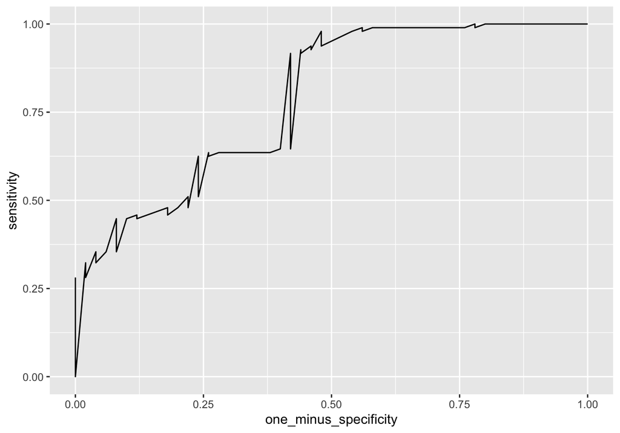

## Decision Tree

This model performs well. It has a 72% accuracy and a high Kappa value. It performs 7% better than the baseline model. Accuracy : 0.72 Kappa : 0.3794  
Sensitivity : 0.6000  
Specificity : 0.7812

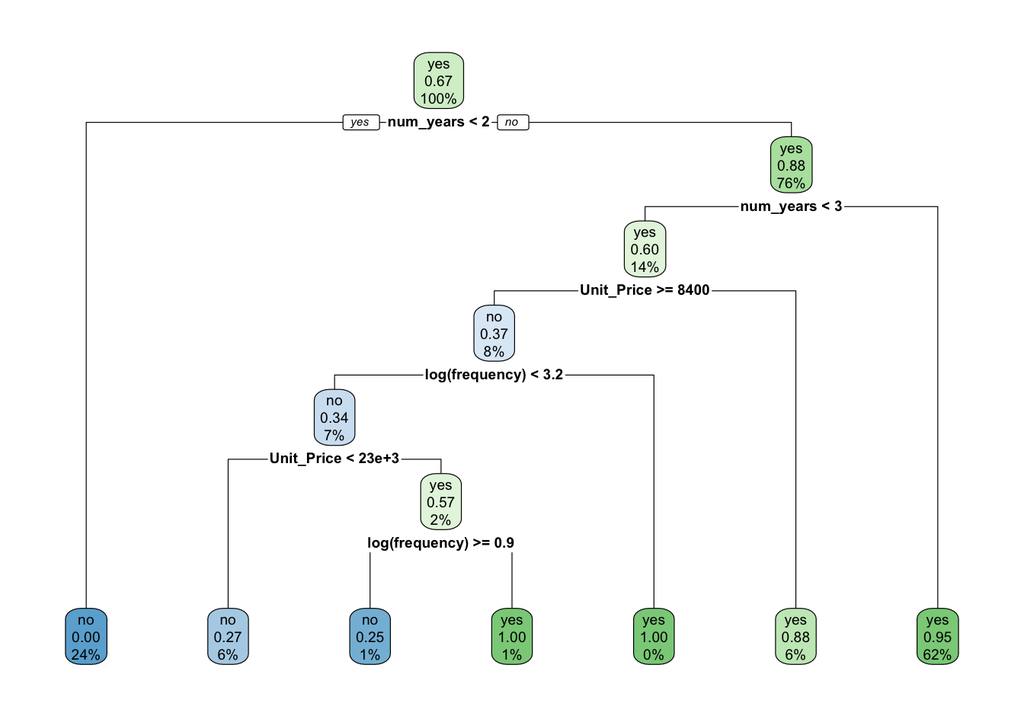

```r
tree <- rpart(Stayed ~num_years + Unit_Price+ log(frequency), data=train, minsplit=3)
#summary(tree)
rpart.plot(tree)
```

```r
test$DT_pred <- predict(tree, test, type="class")
# Test for accuracy of the model.
#confusionMatrix(test$DT_pred, test$Stayed)
```

## Random Forest

With the highest accuracy and highest Kappa value, this algorithm is considered the best algorithm (Kumar and Chandrakala (2016)). It has a high accuracy and a high Kappa value. Sensitvity and Specificity were also high. Accuracy : 0.85  
Kappa : 0.6005  
Sensitivity : 0.5800  
Specificity : 0.9688

```r
train<-train %>%
  drop_na()
rf <- randomForest(Stayed ~Unit_Price+ frequency+ num_years, data = train)
test$pred_rf <- predict(rf, test, type="class")
#confusionMatrix(as.factor(test$pred_rf), test$Stayed)
```

## Support Vector Machines

```r
svm<- svm(Stayed ~ log(frequency) + Unit_Price+ num_years, data = train)
test$pred_svm <- predict(svm, test)
#confusionMatrix(as.factor(test$pred_svm), test$Stayed)
```

## Naive Bayes

Accuracy : 0.7671 Kappa : 0.3893 Sensitivity : 0.3400  
Specificity : 0.9896

```r
nb<- naive_bayes(Stayed ~ frequency + log(Units) + Unit_Price+ num_years, data = train)
test$pred_nb <- predict(nb, test)
#confusionMatrix(as.factor(test$pred_nb), test$Stayed)
```

# Conclusion

This paper aimed to predict my family’s business customer churn to improve the company’s sales performance and consumer retention. We gained valuable insights by analyzing and preparing the company’s data, producing visualizations, and building various forecasting models to predict the consumers’ churn. Additionally, we created a model with a 20 percent increase from the baseline performance, with Random Forest being our best-performing model at 85% accuracy on the test set. This model will give the company a better understanding of the company’s churn pattern and will improve business decisions. In the future, I plan to continue cleaning the data even more to improve my model accuracy. Second, I plan on doing the same analysis on the company’s second most revenue-generating product, binders. The final step in this project is to do prescriptive analytics of my family’s business. To provide intelligent recommendations for the optimal next steps for lowering customer churn on lever arches and binders to drive desired outcomes or accelerate results. Throughout the research, It became clear that the company had a high churn rate, which is problematic, but it had a reasonable revenue growth rate, frequency rate, and product return rate during the six years. Additionally, the number of years a customer has stayed was the most critical factor in our analysis; unit price and frequency of purchasing during the year also had a statistical significance. Therefore, to improve the company and lower churns, the company needs to pay special attention to these three factors and build actionable plans.

# Bibliography

Ahmad, Abdelrahim Kasem, Assef Jafar, and Kadan Aljoumaa. 2019. “Customer Churn Prediction in Telecom Using Machine Learning in Big Data Platform.” *J. Big Data* 6 (1). Springer Science; Business Media LLC.

Kriti. 2019. “Customer Churn: A Study of Factors Affecting Customer Churn Using Machine Learning.” In.

Kumar, A., and D. Chandrakala. 2016. “A Survey on Customer Churn Prediction Using Machine Learning Techniques.” *International Journal of Computer Applications* 154: 13–16.

Vafeiadis, T., K.I. Diamantaras, G. Sarigiannidis, and K.Ch. Chatzisavvas. 2015. “A Comparison of Machine Learning Techniques for Customer Churn Prediction.” *Simulation Modelling Practice and Theory* 55: 1–9. https://doi.org/https://doi.org/10.1016/j.simpat.2015.03.003.